# 热工基础 · 第 2 讲：理想气体与热力过程

刘训臣

山东科技大学 机械电子工程学院

# 第〇部分 · 课程介绍、状态方程与理想气体模型

- 教学内容与主线、7 次课进度表
- 本讲定位：第 1 讲给了框架，本讲给第一个可算的例子
- 状态方程与气体常数 $R$、$R_g$
- 理想气体的四条假设与微观模型

## 第 2 讲：教学内容与主线

> **两个课时、一条主线：从配分函数到 Carnot 效率。**

**课时 1 · 理想气体：从微观到宏观**

- 理想气体的四条假设；单粒子配分函数 $q$（平动为主）
- $N$ 个全同粒子：$Q=q^N/N!$
- 导出 $U=\frac32Nk_BT$、$pV=Nk_BT$、$\mu=\mu^\circ+k_BT\ln(p/p^\circ)$、**Sackur–Tetrode 熵**

## 课时 2：本课时内容

- 熵变的两条路径与统一形式；等温、绝热、**多变过程**（$pV^n$ 一族）
- $w$、$w_t$、$q$、$\Delta s$ 的成套公式；$p$-$v$ 图与 $T$-$s$ 图
- **每个过程一个数值算例**：1 kg 空气、$p_1=0.100$ MPa、$T_1=300$ K 出发
- **Carnot 循环、Carnot 定理与热力学温标**

> 一句话：**课时 1 造出 $S(U,V,N)$，课时 2 用它算过程。**

## 教学进度 · 7 次课全览

| 次 | 教材章 | 主题 | 课时 1 / 课时 2 |
| --- | --- | --- | --- |
| 1 | 第 1、2 章 | 基本概念、统计热力学与热力学基本定律 | 基本概念与统计力学图像 / 热力学基本定律与函数 |
| **2** | **第 3 章** | **理想气体与热力过程** | **理想气体（状态方程、内能、熵） / 热力过程与 Carnot 循环** |
| 3 | 第 4、5 章 | 气体混合、水蒸汽、湿空气与气体流动 | 气体混合物、水蒸汽与湿空气 / 气体流动与喷管 |
| 4 | 第 6、7 章 | 压气机与动力循环、制冷循环 | 压气机与气体动力循环 / 蒸汽动力循环与制冷循环 |
| 5 | 第 8、9 章 | 导热 | 三种传热方式与 Fourier 导热定律 / 稳态导热与热阻分析 |
| 6 | 第 10 章 | 对流换热 | 对流机理与边界层、准则数 / 准则关联式及其应用 |
| 7 | 第 11、12 章 | 热辐射、换热器与总复习 | 热辐射基本定律与辐射换热计算 / 换热器与全课程总复习 |

## 本讲在课程中的位置（一）

**第 1 讲**建立了公理化框架：熵是原语，$T,p,\mu$ 由熵的偏导定义，$S(U,V,N)$ 含全部信息。

**第 2 讲**回答第一个具体问题：**理想气体的 $S(U,V,N)$ 到底长什么样？**

- 路径：**微观（配分函数）→ 宏观（状态方程、内能、熵）**
- 课时 1：从能级到配分函数，再导出 $U$、$p$、$\mu$、$S$——**Sackur–Tetrode 公式**
- 课时 2：$S$ 有了就能算**过程**：等温、绝热、多变的 $w$、$q$、$\Delta s$
- 收口：**Carnot 循环与效率上限** $\eta=1-T_3/T_1$

> 一句话：**先造出 $S(U,V,N)$，再立刻用它算工程过程。**

## 本讲定位（二）：推导留给 AI

**推导留给 AI**：

- ① 问他”为什么必须先有 $S(U,V,N)$ 才能算过程”
- ② 让他比较”统计力学路线”与”经验状态方程路线”得到 $U=\frac32Nk_BT$ 的差别。

## 状态方程与气体常数：三个形式

**理想气体状态方程**（克拉贝龙方程，教材第 3 章第一节）：

$$pv=R_gT,\qquad pV=mR_gT,\qquad pV=nRT,\qquad R=MR_g$$

- $R_g$：**气体常数**，J/(kg·K)，**随气体种类而变**（$R_g=R/M$）
- $R$：**通用气体常数**，$R=8.314\ \text{J/(mol·K)}=8314.3\ \text{J/(kmol·K)}$，**与种类无关**（真题考点）

## 状态方程：常见气体的气体常数

| 气体 | $M$ (g/mol) | $R_g$ J/(kg·K) |
| --- | --- | --- |
| 空气 | 28.97 | 287 |
| O₂ | 32.00 | 260 |
| N₂ | 28.01 | 297 |
| CO₂ | 44.01 | 189 |
| H₂ | 2.016 | 4124 |

**适用条件**：压力不太高、温度不太低（即 $p\to0$、$v\to\infty$ 的极限）。 工程判据：常压常温下的空气、燃气、烟气都可用；高压或近临界时必须用真实气体状态方程。

**推导留给 AI**：

- ① 让他核对上表每一行的 $R_g=R/M$（$R=8.314$ J/(mol·K)）
- ② 问他”为什么 $R$ 与气体种类无关，而 $R_g$ 有关”（提示：$R$ 是摩尔量口径，$R_g$ 是质量口径）。

## 理想气体假设（一）：四条

**理想气体**（ideal gas）＝满足以下四条的模型气体：

1. **分子本身不占体积**（体积全部是自由空间）
2. **分子间无相互作用**（除弹性碰撞瞬间）
3. **全同且不可分辨**（同种分子交换不产生新微观态）
4. **能量量子化**：平动能量取分立值，只是间距极小、可当连续

## 理想气体假设（二）：两个后果

**两个直接后果**：

- 内能只剩**动能** ⇒ $U=U(T)$，与 $V$、$p$ 无关
- 无相互作用 ⇒ 多体问题**拆成单粒子问题**（这是能用配分函数的前提）

> 工程口径：理想气体是 $p\to0$ 的极限；常温常压下空气、燃气、烟气都可当理想气体。

**推导留给 AI**：

- ① 让他说明第 2 条为什么能推出 $U=U(T)$
- ② 问他真实气体在什么条件下明显偏离（提示：高压、低温、近临界点）。

## 理想气体的微观模型

- 全同、无相互作用的单原子气体
- 单粒子配分函数 $q$，$N$ 粒子总配分函数：

$$Q = \frac{1}{N!}q^N$$

# 第一部分 · 理想气体：从微观到宏观

- 配分函数路线：$q\to Q\to$ 全部宏观量
- 单粒子能级：方势阱模型
- 平动配分函数：一维 → 三维
- 热波长 $\Lambda$ 与理想气体判据

## 配分函数路线（一）：三步逻辑链

**课时 1 的逻辑链**：

$$\underbrace{q}_{\text{单粒子配分函数}}\ \longrightarrow\ \underbrace{Q=\frac{q^N}{N!}}_{\text{全同粒子}}\ \longrightarrow\ \underbrace{U,\ p,\ \mu,\ S}_{\text{全部宏观量}}$$

- **第一步**：算单粒子配分函数 $q$（平动占绝对主导：$q=V/\Lambda^3$）
- **第二步**：$N$ 个全同粒子 ⇒ $Q=q^N/N!$（$1/N!$ 治”吉布斯佯谬”）
- **第三步**：套第 1 讲的公式

$$U=-\frac{\partial\ln Q}{\partial\beta},\qquad p=\frac{1}{\beta}\frac{\partial\ln Q}{\partial V},\qquad S=k_B\ln Q+\frac{U}{T}$$

## 配分函数路线（二）：方法论与推导

> 方法论：**统计力学只剩一件事——算配分函数**，其余全是偏导数。

**推导留给 AI**：

- ① 让他逐条核对上面三个公式来自第 1 讲 2.8 的哪几条
- ② 问：若分子还有转动、振动，$q$ 怎么写？（提示：能量相加 ⇒ 配分函数相乘，$q=q_{\rm trans}q_{\rm rot}q_{\rm vib}$）

## 单粒子能级

“粒子在箱中”（particle in a box）模型：

$$E_n = \frac{h^2}{8mL^2}n^2$$

与第 1 次课的方势阱相同。

## 一维配分函数（一）：能级与求和

一维方势阱的能级 $E_n=\dfrac{h^2}{8mL^2}n^2$（$n=1,2,3,\dots$），记基态能级 $\varepsilon_1=\dfrac{h^2}{8mL^2}$，则**各能级相对基态**：

$$\varepsilon_n=(n^2-1)\varepsilon_1$$

于是单粒子一维平动配分函数

$$q_L=\sum_{n=1}^{\infty}e^{-\beta\varepsilon_n}=\sum_{n=1}^{\infty}e^{-\alpha n^2},\qquad \alpha=\frac{\beta h^2}{8mL^2}$$

## 一维配分函数（二）：求和化积分

**关键判据**：$\alpha\ll1$ 时相邻项的指数几乎相同，求和可用积分代替

$$q_L\approx\int_0^{\infty}e^{-\alpha n^2}\,dn=\frac12\sqrt{\frac{\pi}{\alpha}}=\left(\frac{2\pi m}{h^2\beta}\right)^{1/2}L$$

- 线性依赖 $L$（不是 $L^3$——三维才给出 $V$）
- 室温下 $\alpha\sim10^{-17}$，所以”求和化积分”**误差小到无法测量**

**推导留给 AI**：

- ① 让他用 $m=4.65\times10^{-26}$ kg（N₂）、$L=0.1$ m、$T=300$ K 算出 $\alpha$ 的数量级
- ② 问他 $\alpha$ 在什么条件下不再小（提示：极低温、极小容器、极轻粒子——如电子的量子点）。

## 平动配分函数：一维

求和化积分：

$$q_L = \sum_{n=1}^\infty e^{-(n^2-1)\beta\epsilon_1} \approx \left(\frac{2\pi m}{h^2\beta}\right)^{1/2}L$$

**一维结果**（上一页）：$q_L=\left(\dfrac{2\pi m}{h^2\beta}\right)^{1/2}L$

## 平动配分函数：三维结果

**三维**只需把 $L$ 换成 $V$、指数换成 $3/2$：

$$q_V = \frac{V}{\Lambda^3}, \qquad \Lambda = \frac{h}{(2\pi m k_B T)^{1/2}}$$

**数量级**（N₂，298 K，$V=1$ L）：$\Lambda\approx19$ pm ⇒ $q_V\approx1.4\times10^{29}$。

- $q_V$ 极大 ⇒ 能级几乎连续 ⇒ **经典极限成立**（这正是能”求和化积分”的原因）
- 反过来若 $q_V\sim1$，就必须用量子统计（Bose/Fermi）

**$\Lambda$ 是热波长**（量纲为长度）：$q_V=\dfrac{V}{\Lambda^3}$——分子是”多大地方”，分母是”一个热波包占多大”。

## 三维配分函数（一）：三维积分

三维能级 $\varepsilon=\dfrac{h^2}{8mL^2}(n_x^2+n_y^2+n_z^2)$，求和化为**三维积分**：

$$q_V=\iiint_0^{\infty}e^{-\alpha(n_x^2+n_y^2+n_z^2)}\,dn_x dn_y dn_z
=\left(\frac{\pi}{4\alpha}\right)^{3/2}=\left(\frac{2\pi m k_BT}{h^2}\right)^{3/2}V=\frac{V}{\Lambda^3}$$

## 三维配分函数（二）：怎么读 V/Λ³

**怎么读这个结果**：

- $q_V$ **正比于体积**（所以 $p=\frac{1}{\beta}\partial_V\ln Q$ 才会给出 $pV=Nk_BT$）
- $q_V$ **正比于 $T^{3/2}$**（温度升高、可及能级变多）
- $\Lambda=h/\sqrt{2\pi mk_BT}$ 是**热波长**：$V/\Lambda^3$ = “体积里能装下多少个热波包”

> 这个式子是理想气体全部性质的源头——$U$、$p$、$\mu$、$S$ 都是从它求偏导得来的。

**推导留给 AI**：

- ① 让他把三维积分算完（提示：$\int_0^\infty e^{-\alpha x^2}dx=\frac12\sqrt{\pi/\alpha}$ 用三次）
- ② 问：若把容器换成非立方体（如圆柱），$q_V$ 还是 $V/\Lambda^3$ 吗？

## 热波长的数值

- H₂，1 bar，298 K：$\Lambda \approx 71\,\text{pm}$
- 分子平均间距约 3 nm
- $\Lambda \ll$ 分子间距 → 可作理想气体

## 热波长与理想气体判据（数值）

**判据**：$\Lambda^3\ll\dfrac{V}{N}$（每个粒子的自由体积），即粒子波包互不重叠。

| 气体 | 条件 | $\Lambda$ | 与前均间距之比 |
| --- | --- | --- | --- |
| H₂ | 1 bar, 298 K | $\approx71$ pm | $71\ \text{pm}/3.3\ \text{nm}\approx0.02$ |
| N₂ | 1 bar, 298 K | $\approx19$ pm | $\approx0.006$ |

- 常温常压下 $\Lambda\ll$ 平均间距（约 3 nm）⇒ 量子交换效应可忽略 ⇒ **经典理想气体**
- 反例（必须用量子统计）：液氦（低温高密度）、金属中的电子气、光子气
- $\Lambda$ 随 $T$ 降低而增大 ⇒ **降温或加压会让理想气体失效**

**推导留给 AI**：

- ① 让他算出液氦（$T=4$ K、密度 0.145 g/cm³）的 $\Lambda$ 与平均间距之比
- ② 问他”为什么光子气永远不能用理想气体模型”（提示：光子数不守恒、化学势为零）。

## N 粒子配分函数

$$Q(\text{NVT}) = \frac{1}{N!}\left(\frac{V}{\Lambda^3}\right)^N$$

**$1/N!$ 从哪来**：全同粒子交换不产生新微观态，$q^N$ 把 $N!$ 种排列当成了不同状态 ⇒ 必须除掉。

- 这是**吉布斯佯谬**的解药：不除 $1/N!$，同种气体混合会算出”混合熵”，且熵不满足广延性
- 宏观后果：$\ln Q=N\ln q-\ln N!\approx N\ln\frac{q}{N}+N$（Stirling）——**$q/N$ 的出现保证了广延性**

有了 $Q$，理想气体的**一切热力学性质**都可求出。

# 第二部分 · 从配分函数到宏观量

- 内能 $U=\frac32Nk_BT$、状态方程 $pV=Nk_BT$、化学势 $\mu$
- 比热容与迈耶公式 $c_p-c_v=R_g$
- Sackur–Tetrode 熵与标准态熵 $S^\circ(T)$
- 数值检验：与 JANAF 表对照

## 内能

**内能的完整推导链**（$Q=\dfrac{1}{N!}\left(\dfrac{V}{\Lambda^3}\right)^N$，$\Lambda\propto\beta^{-1/2}$）：

$$\langle U\rangle=\left.\frac{\partial\ln Q}{\partial(-\beta)}\right|_V
=-\frac{1}{Q}\left.\frac{\partial Q}{\partial\beta}\right|_V
=\frac{1}{Q}\frac{V^N}{N!}\frac{3N}{\Lambda^{3N+1}}\frac{d\Lambda}{d\beta}$$

$$=\frac{1}{Q}\frac{V^N}{N!}\frac{3N}{\Lambda^{3N+1}}\frac{\Lambda}{2\beta}
=\frac{3N}{2\beta}=\frac{3}{2}Nk_BT$$

- 关键一步：$\Lambda\propto\beta^{-1/2}\Rightarrow\dfrac{d\Lambda}{d\beta}=\dfrac{\Lambda}{2\beta}$（对数求导）
- 与分子运动论一致：$U = \frac{3}{2}nRT$；每个粒子每个平动自由度贡献 $\tfrac12 k_BT$

## 化学势

**化学势的完整推导链**（$q=q_{\rm int}\,q_V$，内部自由度只依赖温度）：

$$\mu=-k_BT\ln\frac{q}{N}
=-k_BT\ln\frac{q_{\rm int}q_V}{N}
=-k_BT\ln\left(q_{\rm int}\frac{k_BT}{p\Lambda^3}\right)$$

$$=-k_BT\ln\left(q_{\rm int}\frac{k_BT}{p^\circ\Lambda^3}\right)+k_BT\ln\frac{p}{p^\circ}
=\mu^\circ(T)+k_BT\ln\frac{p}{p^\circ}$$

理想气体化学势含**对数压力依赖**：压力项 $k_BT\ln(p/p^\circ)$ 来自**平动**（因 $q_V\propto1/p$），与内部自由度无关——这是质量作用定律（第 3 次课）的源头。

- $\mu^\circ(T)$ 只含温度（标准态 1 bar 的值）
- 对数项是**质量作用定律**与 van’t Hoff 方程的源头（第 3 次课）
- 平衡判据 $\mu_1=\mu_2$ 在这里第一次有了可算的形式

## 状态方程

$$\beta p = \left.\frac{\partial \ln Q}{\partial V}\right|_\beta = \frac{N}{V} = \rho$$

$$pV = Nk_BT = nRT$$

**每个粒子的体积功**：$p\,\dfrac{V}{N}=k_BT$——每粒子尺度上的能量标度。

**数值核对**：1 mol 理想气体在 273.15 K、101.325 kPa 下的体积

$$V_m=\frac{RT}{p}=\frac{8.314\times273.15}{101\,325}=22.41\ \text{L/mol}\quad\checkmark$$

与标准摩尔体积一致——**状态方程也是从配分函数推出来的**，不是额外假设。

## 比热容：定义与真实比热

**定义**（真实比热容，教材第二节）：

$$c=\frac{\delta q}{dT},\qquad c_v=\left(\frac{\partial u}{\partial T}\right)_v,\qquad c_p=\left(\frac{\partial h}{\partial T}\right)_p$$

## 比热容：三种工程处理方式

**理想气体的三种工程处理**（精度递增）：

1. **定值比热容**（由能量均分原理）：$c_{V,m}=\frac32 R$（单原子）、$\frac52R$（双原子）；$c_{p,m}=c_{V,m}+R$
2. **平均比热容表**：查表得 $\bar c\big|_{t_1}^{t_2}$，则 $q=\bar c\big|_{t_1}^{t_2}(t_2-t_1)$（真实比热随温度变化，用平均值最准）
3. **平均比热的直线关系式** + 气体热力性质表：工程手册做法

> 理想气体的摩尔定压/定容热容在定值近似下是常数；**真实比热容随温度升高而增大**（振动自由度被激发）——这是后续所有计算的精度来源。

**推导留给 AI**：

- ① 让他解释 $c_p>c_v$ 的物理原因，并核对 $c_{p,m}-c_{V,m}=R$
- ② 问：“为什么用平均比热容表算热量，比用定值比热容准？”（提示：热量是 $\int c\,dT$，比热随 $T$ 变化时取平均才等价。）

## 例题 3-2（一）：锅炉空气预热器

**题**：某锅炉空气预热器将空气从 20 ℃ 定压加热到 262 ℃，空气流量折合到标准状态为 5000 m³/h，求每小时加给空气的热量。（分别按定值比热容、平均比热容表、平均比热直线关系式、空气热力性质表计算）

## 例题 3-2（二）：四种算法的比较

**推导留给 AI**：

- ① 让他把四种算法的数值都算出来并列表比较（标准状态按 0 ℃、101.325 kPa）
- ② 问他”为什么标准状态流量要换算成摩尔流量再乘 $c_{p,m}$”
- ③ 让 AI 检查你的单位换算（m³/h → mol/s）。

## 内能与焓（一）：两个宏观公式

**微观结果与工程公式完全一致**：

$$\Delta u=c_v\Delta T,\qquad \Delta h=c_p\Delta T\qquad(\text{理想气体})$$

- $u=u(T)$：无相互作用 ⇒ 只剩动能 ⇒ 只依赖温度
- $h=u+pv=u(T)+R_gT$ ⇒ $h=h(T)$，也只依赖温度
- 两者之差 $pv=R_gT$ ⇒ **迈耶公式**：$c_p-c_v=R_g$（摩尔量：$c_{p,m}-c_{v,m}=R$）
- 因为 $c_p>c_v$，故 $\gamma=c_p/c_v>1$：单原子 $5/3$、双原子 $7/5$

## 内能与焓（二）：工程为什么用焓

**为什么工程用焓**：开口系（锅炉、换热器、喷管、汽轮机）的能量方程天然含 $h$——它自动包含流动功 $pv$。

**推导留给 AI**：

- ① 用 $h=u+pv$ 与 $pv=R_gT$ 推迈耶公式
- ② 问他”$c_p$ 为什么大于 $c_v$“（提示：定压加热时气体还要对外膨胀做功）
- ③ 核对 $\gamma$ 的两个数值怎么来的。

## 热容

**定义链**（热容 = 热力学函数对温度的偏导）：

$$C_V=\left.\frac{\partial U}{\partial T}\right|_V
\Rightarrow\ \hat c_V=\frac32 k_B;
\qquad
C_p=\left.\frac{\partial H}{\partial T}\right|_p=\left.\frac{\partial(U+pV)}{\partial T}\right|_p
\Rightarrow\ \hat c_p=\frac52 k_B$$

- 单原子：$C_V=\frac32Nk_B$、$C_p=\frac52Nk_B$；双原子（N₂、O₂）：$\hat c_V=\frac52k_B$、$\hat c_p=\frac72k_B$
- 迈耶关系：$C_p-C_V=Nk_B$（因为 $\partial(U+pV)/\partial T|_p=\partial U/\partial T|_V+Nk_B$）
- $\gamma=C_p/C_V=5/3\approx1.667$（单原子）；双原子 $\gamma=7/5=1.4$

| 气体 | $\hat c_V$ | $\hat c_p$ |
| --- | --- | --- |
| 单原子（He、Ar） | $\tfrac32 k_B$ | $\tfrac52 k_B$ |
| 双原子（N₂、O₂） | $\tfrac52 k_B$ | $\tfrac72 k_B$ |

**由 $Q$ 求 $S$**：$S=k_B\ln Q+\dfrac{U}{T}$，代入 $Q=q^N/N!$ 与 $U=\frac32Nk_BT$。

## 熵：Sackur–Tetrode 公式（全讲熵变计算的出发点）

> **这一页是全讲熵变计算的出发点**：课时 2 里等温、绝热、多变过程的 $\Delta s$ 公式，全部是对这里的 $S$ 求差（或对 $dS$ 积分）得到的。

**由 $Q$ 求 $S$**：把 $Q=q^N/N!$ 与 $U=\frac32Nk_BT$ 代入 $S=k_B\ln Q+\dfrac{U}{T}$：

$$\frac{S}{N}=k_B\left(\ln q_{V/N}+\frac52\right)=k_B\ln\frac{e^{5/2}k_BT}{p\Lambda^3},
\qquad q_{V/N}=\frac{k_BT}{p\Lambda^3}$$

- $q_{V/N}$ 是”平均每个粒子分到的体积”对应的配分函数
- 第一项来自平动状态数，$5/2$ 来自内能项（$3/2$ 内能 + $1$ 来自 $1/N!$）

**摩尔熵**（$N=N_A$、$p=1$ bar、$T=298$ K）：

$$\bar S=\frac{S}{n}=R\Big[\underbrace{\ln\frac{k_BT}{p\Lambda^3}}_{\ln(V/N\Lambda^3)\ \text{的等价写法}}+\frac52\Big]$$

## Sackur–Tetrode 数值（二）：算一遍 Ar

**算一遍 Ar**（$M=39.95$ g/mol ⇒ $\Lambda=16.0$ pm）：

[output not shown]

- 与热化学表（JANAF：Ar，298 K，$S^\circ=154.8$ J/(mol·K)）**吻合**——这是统计力学最漂亮的一次定量胜利
- 只用了 $m$、$h$、$k_B$ 三个常数，没有任何可调参数

## Sackur–Tetrode 数值（二）：算一遍 Ar（推导）

**推导留给 AI**：

- ① 让他独立复算上表（提醒 $p$ 用 Pa、$\Lambda$ 用 m）
- ② 问：为什么 $\bar S$ 随压力升高而**减小**（提示：$\ln p$ 项）
- ③ 与第 3 次课 JANAF 表的用法对接。

## 标准态熵（一）：标准态形式

Sackur–Tetrode 的”标准态”形式（$p^\circ=1$ bar）：

$$\mu=\mu^\circ+k_BT\ln\frac{p}{p^\circ},\qquad
s^\circ(T)=k_B\left[\ln\frac{e^{5/2}k_BT}{p^\circ\Lambda^3}+\ln q_{\rm int}\right]$$

## 标准态熵（二）：与 JANAF 表的接口

**关键点**：

- $q_{\rm int}$（转动、振动、电子）**只依赖温度**，所以 $\mu^\circ$、$s^\circ$ 也只依赖 $T$
- $\mu^\circ(T)$ 就是**标准态化学势**；JANAF 表里的 $S^\circ(T)$ 就是 $s^\circ(T)$ 的实测值
- 本页把”统计力学算出的绝对熵”与”手册里的标准态熵”接上——**第 3 次课直接用这张表算化学平衡**

> 注意：$k_B\ln[k_BT/(p^\circ\Lambda^3)]$ 里的 $k_BT/p^\circ$ 就是**标准态下每个粒子的体积**， 与前面”每粒子自由体积”的口径一致。

**推导留给 AI**：

- ① 让他核对 $\mu^\circ$ 与 $s^\circ$ 的关系（$\mu^\circ=h^\circ-Ts^\circ$）
- ② 问：为什么 $q_{\rm int}$ 不影响 $\mu$ 对压力的依赖？

## 熵的 NVU 形式

**把 $T$ 换成 $U$**（用 $U=\frac32Nk_BT$ 反解 $T$），就得到以 $(U,V,N)$ 为自变量的熵——这正是热力学要求的基本形式。

$$S(U,V,N) = Nk_B\left[\ln\left(\frac{V}{N}\left(\frac{4\pi m}{3h^2}\frac{U}{N}\right)^{3/2}\right) + \frac{5}{2}\right]$$

**线性组合形式**（便于求偏导）：

$$S=Nk_B\left(\frac32\ln\frac{U}{N}+\ln\frac{V}{N}+S_0\right),\qquad
S_0=\frac32\ln\frac{4\pi m}{3h^2}+\frac52$$

## 思考题：大气压力的 Boltzmann 分布

**这是 Boltzmann 分布最常见的宏观实例**：$n(z)\propto e^{-mgz/k_BT}$。

重力场中压力随高度指数下降：

$$p(z) = p_0\,e^{-mgz/k_BT} = p_0\,e^{-z/H}, \qquad H = \frac{k_BT}{mg}$$

**数值**：标高 $H=k_BT/mg\approx8.4$ km（288 K）⇒ 珠峰（8 848 m）气压约为海平面的 $e^{-1.05}\approx1/3$。

## 思考与提问 · 理想气体（课时 1）

> **开放性问题**（没有唯一答案）：先自己想，再让 AI 帮你查证、找反例，最后形成你自己的答案。
1. Sackur–Tetrode 公式里同时出现 $h$、$m$、$k_B$——**三个常数一个都不少**。这说明”熵的绝对值”依赖于量子力学与原子质量。那么经典热力学（只用 $p,V,T$）为什么给不出熵的绝对值？
2. 热波长 $\Lambda$ 是判断”能不能当经典理想气体”的尺子。请让 AI 帮你估算：**液氦（4 K）中的氦原子**、**金属中的自由电子**、**恒星内部的等离子体**，哪个最先失效？依据是什么？
3. 吉布斯引入 $1/N!$ 之前，同种气体混合会出现”混合熵不为零”的佯谬。请说明：$1/N!$ 究竟是数学技巧，还是”全同粒子不可分辨”这条物理假设的必然结果？让 AI 举一个反例来挑战你的结论。

## 课时 1 小结

**一条链**（本课时全部内容的骨架）：

$$q_L \to q_V=\frac{V}{\Lambda^3} \to Q=\frac{q^N}{N!} \to U,\ p,\ \mu,\ S$$

- **内能** $U=\frac32Nk_BT$；**状态方程** $pV=Nk_BT=nRT$（$R_g=R/M$）；每粒子体积功 $pV/N=k_BT$
- **化学势** $\mu=\mu^\circ+k_BT\ln(p/p^\circ)$——压力项来自平动，是质量作用定律的源头
- **比热容** $C_V=\frac32Nk_B$、$C_p=\frac52Nk_B$；迈耶公式 $c_p-c_v=R_g$
- **熵** Sackur–Tetrode：$S/N=k_B(\ln q_{V/N}+5/2)$，摩尔熵与热化学表吻合（零可调参数）

> 一句话：**理想气体的宏观性质完全由 $q$ 决定**——剩下的一切都是偏导数与求差。

# 第三部分 · 基本热力过程与熵变

- 定容、定压、定温、绝热四个过程
- 每个过程的 $p$-$v$ 图与 $T$-$s$ 图
- 过程方程、功、热量、熵变
- 熵变的两条路径与统一形式
- 每个过程配**数值算例**：1 kg 空气、$p_1=0.100$ MPa、$T_1=300$ K 出发，逐项算 $w$、$q$、$\Delta u$、$\Delta s$

## 定容过程：p-v 图与 T-s 图

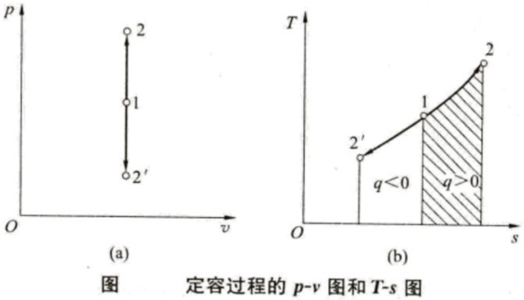

定容过程的 p-v 图与 T-s 图

- **过程方程**：$v=C$（$p/T=C$）；**功** $w=0$；**热量** $q=\Delta u=c_v\Delta T$
- **熵变**：$\Delta s=c_v\ln(T_2/T_1)$；T-s 图下方面积 = 热量
- **微观**：能级位置不变，吸热只改变**分布**（粒子往高能级爬）

**推导留给 AI**：

- ① 由 $q=\Delta u+w$ 与 $w=0$ 说明”定容加热的热全部变内能”
- ② 问他 T-s 图上定容线的斜率（提示：$\mathrm{d}T/\mathrm{d}s=T/c_v$）。

## 定容过程：完整参数卡

| 参数 | 值 |
| --- | --- |
| 过程特征 | $V=\text{定值}$（$n=\infty$） |
| $T,p,V$ 关系 | $\dfrac{T_1}{T_2}=\dfrac{p_1}{p_2}$ |
| $\Delta u$ | $C_V(T_2-T_1)$ |
| $\Delta h$ | $C_p(T_2-T_1)$ |
| $\Delta s$ | $C_V\ln\dfrac{T_2}{T_1}$ |
| 比热容 $C$ | $C_V=\dfrac{Nk_B}{\gamma-1}$ |
| 过程功 $w=\int_1^2p\,dV$ | 0 |
| 技术功 $w_t=-\int_1^2V\,dp$ | $V(p_1-p_2)$ |
| 过程热量 $q$ | $\Delta u$ |

## 算例 · 定容加热（$q=\Delta u$，功为零）

| 已知 | 计算 | 结果 |
| --- | --- | --- |
| 1 kg 空气，$p_1=0.100$ MPa，$T_1=300$ K | $v_1=\dfrac{R_gT_1}{p_1}=0.861$ m³/kg | 过程方程 $v=\text{const}$ |
| 定容加热到 $p_2=0.500$ MPa | $T_2=T_1\dfrac{p_2}{p_1}=300\times5$ | $T_2=1500$ K |
| $w=\displaystyle\int p\,\mathrm{d}v$ | $v$ 不变 ⇒ $\mathrm{d}v=0$ | $w=0$ |
| $\Delta u=c_v(T_2-T_1)$ | $0.7175\times(1500-300)$ | $\Delta u=861.0$ kJ/kg |
| $q=\Delta u+w$ | $861.0+0$ | $q=861.0$ kJ/kg（吸热） |
| $\Delta h=c_p\Delta T$ | $1.0045\times1200$ | $\Delta h=1205$ kJ/kg |
| $\Delta s=c_v\ln\dfrac{T_2}{T_1}$ | $0.7175\ln 5$ | $\Delta s=+1.155$ kJ/(kg·K) |

> **第一定律**：$q=861.0=\Delta u+0$——**吸的热全部变成内能**，一点功也没做。 微观：能级不变，粒子往高能级爬。对比下一页定压：同样的温升要**多给一份膨胀功**。

## 定压过程：p-v 图与 T-s 图

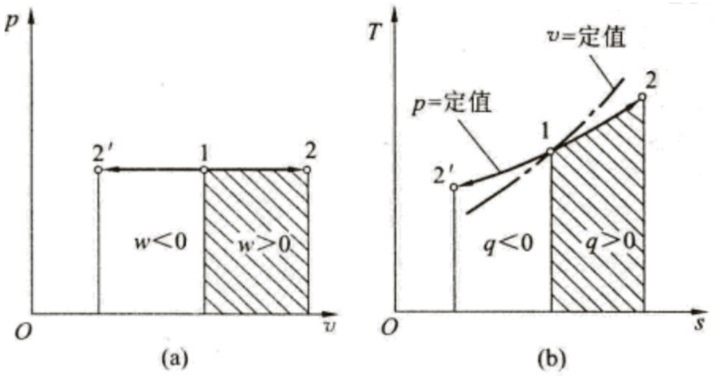

定压过程的 p-v 图与 T-s 图

- **过程方程**：$p=C$（$v/T=C$）；**功** $w=p\Delta v=R_g\Delta T$；**技术功** $w_t=0$
- **热量**：$q=\Delta h=c_p\Delta T$；**熵变** $\Delta s=c_p\ln(T_2/T_1)$
- **工程**：锅炉、换热器都是定压过程——这就是工程量用焓的原因

**推导留给 AI**：

- ① 验证定压 $q=\Delta h$
- ② 问：“为什么定压加热比定容加热需要更多热量？”（提示：多出的部分做了膨胀功。）

## 定压过程：完整参数卡

| 参数 | 值 |
| --- | --- |
| 过程特征 | $p=\text{定值}$（$n=0$） |
| $T,p,V$ 关系 | $\dfrac{T_1}{T_2}=\dfrac{V_1}{V_2}$ |
| $\Delta u$ | $C_V(T_2-T_1)$ |
| $\Delta h$ | $C_p(T_2-T_1)$ |
| $\Delta s$ | $C_p\ln\dfrac{T_2}{T_1}$ |
| 比热容 $C$ | $C_p=\dfrac{\gamma Nk_B}{\gamma-1}$ |
| 过程功 $w$ | $p(V_2-V_1)=Nk_B(T_2-T_1)$ |
| 技术功 $w_t$ | 0 |
| 过程热量 $q$ | $\Delta h$ |

## 算例 · 定压加热（$q=\Delta h$，功 $=p\Delta v$）

| 已知 | 计算 | 结果 |
| --- | --- | --- |
| 同上起点，$p=0.100$ MPa 不变 | $v_1=0.861$ m³/kg | 过程方程 $p=\text{const}$ |
| 定压加热到 $v_2=2v_1$ | $T_2=T_1\dfrac{v_2}{v_1}=300\times2$ | $T_2=600$ K |
| $w=\displaystyle\int p\,\mathrm{d}v=p\Delta v$ | $100\times(1.722-0.861)$ | $w=+86.1$ kJ/kg |
| $\Delta u=c_v\Delta T$ | $0.7175\times300$ | $\Delta u=215.2$ kJ/kg |
| $q=\Delta h=c_p\Delta T$ | $1.0045\times300$ | $q=301.3$ kJ/kg（吸热） |
| 第一定律核对 | $215.2+86.1$ | $=301.3$ ✓ |
| $\Delta s=c_p\ln\dfrac{T_2}{T_1}$ | $1.0045\ln 2$ | $\Delta s=+0.6963$ kJ/(kg·K) |

> **定压比定容”多要”的那一份**：同样升温 300 K，定压要 301.3 kJ/kg、定容只要 215.2 kJ/kg， 差额 $86.1$ kJ/kg 正好等于膨胀功 $p\Delta v$。这就是工程上**用焓**的原因：$q=\Delta h$ 把这份功包进去了。

## 定温过程：p-v 图与 T-s 图

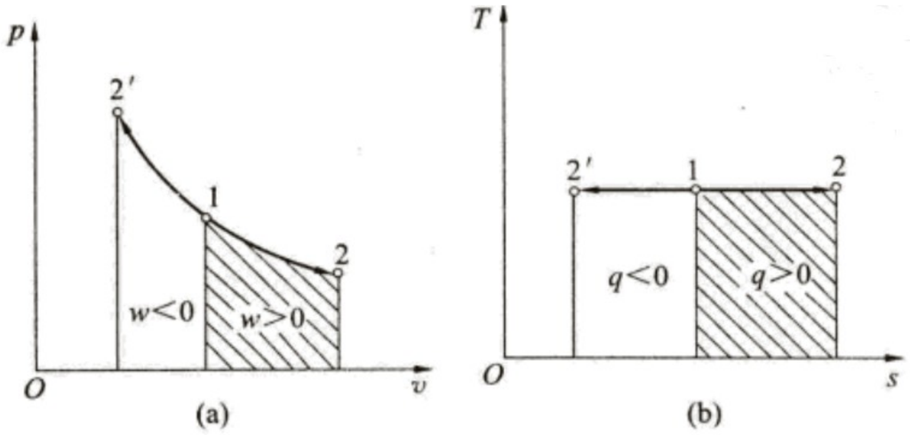

定温过程的 p-v 图与 T-s 图

- **过程方程**：$pv=C$（等轴双曲线）；**$\Delta u=0$** ⇒ $q=w$
- **功**：$w=Nk_BT\ln\dfrac{v_2}{v_1}$；**熵变**：$\Delta s=Nk_B\ln\dfrac{v_2}{v_1}$
- **微观**：$T$ 不变 ⇒ 分布形状不变；膨胀时能级间距变小，粒子重新分布以保持 $T$

**推导留给 AI**：

- ① 用 $\Delta u=0$ 说明”等温吸热全部对外做功”
- ② 问：既然 $T$ 不变、$U$ 不变，为什么还能对外做功？（提示：靠体积膨胀，不是靠降温。）

## 定温过程：完整参数卡

| 参数 | 值 |
| --- | --- |
| 过程特征 | $T=\text{定值}$（$n=1$） |
| $T,p,V$ 关系 | $p_1V_1=p_2V_2$ |
| $\Delta u$ | 0 |
| $\Delta h$ | 0（$T$ 不变） |
| $\Delta s$ | $Nk_B\ln\dfrac{V_2}{V_1}=-Nk_B\ln\dfrac{p_2}{p_1}$ |
| 比热容 $C$ | $\infty$ |
| 过程功 $w$ | $Nk_BT\ln\dfrac{V_2}{V_1}=-Nk_BT\ln\dfrac{p_2}{p_1}$ |
| 技术功 $w_t$ | $w$ |
| 过程热量 $q$ | $T(s_2-s_1)=w=w_t$ |

## 算例 · 定温压缩（$q=w$，$\Delta u=0$）

| 已知 | 计算 | 结果 |
| --- | --- | --- |
| 同上起点，$T=300$ K 不变 | $T_1=T_2$ | 过程方程 $pv=\text{const}$ |
| 定温压缩到 $p_2=0.500$ MPa | $v_2=v_1\dfrac{p_1}{p_2}=\dfrac{0.861}{5}$ | $v_2=0.1722$ m³/kg |
| $\Delta u=c_v\Delta T$ | $\Delta T=0$ | $\Delta u=\Delta h=0$ |
| $w=R_gT\ln\dfrac{v_2}{v_1}$ | $0.287\times300\times\ln\dfrac{1}{5}$ | $w=-138.6$ kJ/kg |
| $q=\Delta u+w$ | $0+(-138.6)$ | $q=-138.6$ kJ/kg（放热） |
| $\Delta s=R_g\ln\dfrac{v_2}{v_1}$ | $0.287\times(-1.6094)$ | $\Delta s=-0.4619$ kJ/(kg·K) |
| 熵与热互检 | $q/T=-138.6/300$ | $=-0.4619=\Delta s$ ✓ |

> **第一定律**：$\Delta u=0$ ⇒ $q=w$，**热与功一对一等量转换**（这里是压缩：外界做功 138.6 kJ， 全部以热的形式排给环境）。把方向反过来就是等温膨胀：**吸的热全部对外做功**。

## 等温过程：功、热与熵变

等温过程只需考虑体积变化（$T$ 固定，$dU=0$）：

- 因为 $dU=0$：**吸的热全部变成功**（理想气体等温膨胀）
- 熵变 $\Delta S=Nk_B\ln\dfrac{V_2}{V_1}$，与 $q=T\Delta S$ 一致 ✓
- $p$-$v$ 图上是等轴双曲线；$T$-$s$ 图上是水平线

## 绝热过程：p-v 图与 T-s 图

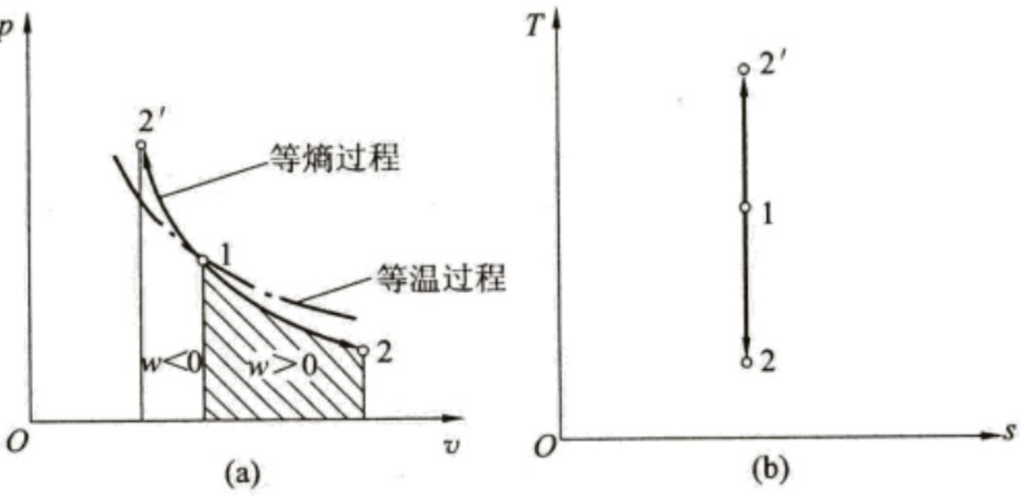

绝热过程的 p-v 图与 T-s 图

- **过程方程**：$pv^{\gamma}=C$（比等温线**更陡**）；**$q=0$** ⇒ $w=-\Delta u$
- **熵变**：$\Delta s=0$（可逆绝热）——T-s 图上是**竖直线**
- **微观**：能级随体积下移而**分布不变**（$S$ 只与分布有关）

**推导留给 AI**：

- ① 比较绝热线与等温线的陡峭程度并说明原因（提示：绝热膨胀时 $T$ 同时下降）
- ② 问：“不可逆绝热过程（如自由膨胀）在 T-s 图上怎么画？”（$s$ 增大，不是竖直线。）

## 定熵（可逆绝热）过程：完整参数卡

| 参数 | 值 |
| --- | --- |
| 过程特征 | $s=\text{定值}$（$n=\gamma$） |
| $T,p,V$ 关系 | $p_1V_1^\gamma=p_2V_2^\gamma$；$T_1V_1^{\gamma-1}=T_2V_2^{\gamma-1}$；$T_1p_1^{(1-\gamma)/\gamma}=T_2p_2^{(1-\gamma)/\gamma}$ |
| $\Delta u$ | $C_V(T_2-T_1)$ |
| $\Delta h$ | $C_p(T_2-T_1)$ |
| $\Delta s$ | 0 |
| 比热容 $C$ | 0 |
| 过程功 $w$ | $-\Delta u=\dfrac{Nk_B}{\gamma-1}(T_1-T_2)=\dfrac{Nk_BT_1}{\gamma-1}\left[1-\left(\dfrac{p_2}{p_1}\right)^{(\gamma-1)/\gamma}\right]$ |
| 技术功 $w_t$ | $-\Delta h=\dfrac{\gamma Nk_B}{\gamma-1}(T_1-T_2)=\dfrac{\gamma Nk_BT_1}{\gamma-1}\left[1-\left(\dfrac{p_2}{p_1}\right)^{(\gamma-1)/\gamma}\right]$；$w_t=\gamma w$ |
| 过程热量 $q$ | 0 |

## 算例 · 定熵压缩（$q=0$，$w=-\Delta u$）

| 已知 | 计算 | 结果 |
| --- | --- | --- |
| 同上起点，绝热（$q=0$） | — | 过程方程 $pv^{1.4}=\text{const}$ |
| 压缩到 $p_2=0.500$ MPa | $T_2=T_1\left(\dfrac{p_2}{p_1}\right)^{\frac{\gamma-1}{\gamma}}=300\times5^{0.2857}$ | $T_2=475.15$ K |
| 状态方程给比容 | $v_2=\dfrac{R_gT_2}{p_2}$ | $v_2=0.2727$ m³/kg |
| $\Delta u=c_v\Delta T$ | $0.7175\times175.15$ | $\Delta u=+125.7$ kJ/kg |
| $q=\Delta u+w$，$q=0$ | $w=-\Delta u$ | $w=-125.7$ kJ/kg |
| 技术功 | $w_t=\gamma w=-1.4\times125.7$ | $w_t=-175.9$ kJ/kg（$=-\Delta h$） |
| 熵变 | $c_v\ln\dfrac{T_2}{T_1}+R_g\ln\dfrac{v_2}{v_1}$ | $\Delta s=0$ ✓ |

> **第一定律**：$q=0$ ⇒ $w=-\Delta u$——**压气机的耗功全部变成气体的内能**，所以出口温度升高。 绝热压缩比定温压缩”省功”（$125.7<138.6$ kJ/kg），代价是温度从 300 K 升到 475 K。

## 熵变为什么与路径无关（两种分解对照）

**出发点**：第二部分的 Sackur–Tetrode 熵 $S(T,V,N)$——它的微分就是 $dS=C_V\dfrac{dT}{T}+Nk_B\dfrac{dV}{V}$，路径积分即得下面各式。

**同一个初末态，两条不同路径算熵变**：

| 路径 | 分解 | $\Delta S$ | 微分形式 |
| --- | --- | --- | --- |
| 1 | 定容变压 + 等温变容 | $\frac32Nk_B\ln\frac{U_2}{U_1}+Nk_B\ln\frac{V_2}{V_1}=C_V\ln\frac{T_2}{T_1}+Nk_B\ln\frac{V_2}{V_1}$ | $dS=C_V\frac{dT}{T}+Nk_B\frac{dV}{V}$ |
| 2 | 定压变容 + 等温变压 | $C_V\ln\frac{T_2}{T_1}+Nk_B\ln\frac{T_2}{T_1}-Nk_B\ln\frac{p_2}{p_1}=C_p\ln\frac{T_2}{T_1}-Nk_B\ln\frac{p_2}{p_1}$ | $dS=C_p\frac{dT}{T}-Nk_B\frac{dp}{p}$ |

**两者必须相等**——这不是巧合，而是**熵是状态函数**的直接体现：

- 两条路径都从 $(p_1,V_1)$ 到 $(p_2,V_2)$，状态函数的变化只由端点决定
- 课堂演示：代入 $pV=Nk_BT$ 与 $C_p-C_V=Nk_B$，两式可互相化简为同一形式

## 熵变为什么与路径无关（两种分解对照）（推导）

**推导留给 AI**：

- ① 让他把两式都化成统一形式
- ② 问他”如果两条路径给出不同的熵变，说明什么”（提示：要么算错、要么熵不是状态函数——而后者被公理 III 否定）。

## 熵变的统一形式与绝热过程

**两条路径等价**（约去 $\dfrac{dT}{T}$ 项后的统一形式）：

$$\Delta S = C_V\ln\frac{p_f}{p_i} + C_p\ln\frac{V_f}{V_i},\qquad
dS = C_V\frac{dp}{p} + C_p\frac{dV}{V}$$

**绝热（等熵）过程** $\Delta S = 0$：

$$\frac{dp}{p} = -\gamma\frac{dV}{V}, \qquad pV^\gamma = \text{const}, \qquad \gamma = \frac{C_p}{C_V}$$

- 单原子 $\gamma = 5/3$；双原子 $\gamma = 7/5$

## 绝热（等熵）过程的三个关系式

由 $\Delta S=0$（可逆绝热）出发，代入 $C_V\ln\frac{T_2}{T_1}+Nk_B\ln\frac{V_2}{V_1}=0$ 与 $\gamma=C_p/C_V$：

$$TV^{\gamma-1}=\text{const},\qquad pV^{\gamma}=\text{const},\qquad Tp^{\frac{1-\gamma}{\gamma}}=\text{const}$$

**三个推论**：

- 绝热膨胀：$V\uparrow$ ⇒ $T\downarrow$（气体对外做功，内能减少）——**喷雾降温、气瓶结霜的原理**
- 绝热压缩：$T\uparrow$（柴油机压燃、打气筒发热）
- 声波在气体中的传播近似等熵 ⇒ 声速 $a=\sqrt{\gamma R_gT}$

**推导留给 AI**：

- ① 从 $pV^\gamma$ 出发，用状态方程推导另外两式
- ② 问他”为什么绝热过程必须是可逆的才叫等熵”（提示：不可逆绝热 $\Delta S>0$）。

# 第四部分 · 多变过程与第一定律的应用

- 多变过程 $pV^n$：一族曲线覆盖四种基本过程
- 过程功、技术功、热量与多变热容 $C_n$
- 可逆过程公式总表（定值比热容）
- Maxwell 关系与绝热节流（预告）

## 多变过程：p-v 图与 T-s 图

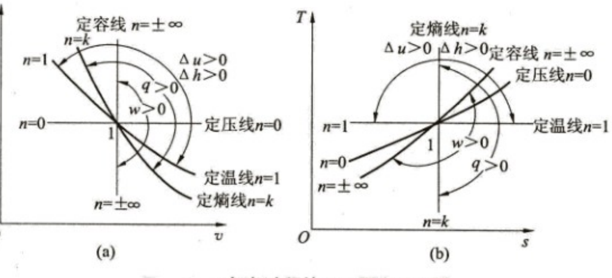

多变过程的 p-v 图与 T-s 图

**推导留给 AI**：让 AI 解释”$n$ 变化时曲线绕 1 点旋转”的规律，并核对 $n=\pm\infty$ 为什么是竖直线。

## 多变过程：完整参数卡

[output not shown]

## 算例 · 多变压缩 $n=1.3$（$q$、$w$ 都要算）

| 已知 | 计算 | 结果 |
| --- | --- | --- |
| 同上起点，$n=1.3$，压到 $0.500$ MPa | $T_2=T_1\left(\dfrac{p_2}{p_1}\right)^{\frac{n-1}{n}}=300\times5^{0.2308}$ | $T_2=434.9$ K |
| $v_2=\dfrac{R_gT_2}{p_2}$ | — | $v_2=0.2497$ m³/kg |
| $w=-\dfrac{R_g(T_2-T_1)}{n-1}$ | $-\dfrac{0.287\times134.9}{0.3}$ | $w=-129.1$ kJ/kg |
| $\Delta u=c_v\Delta T$ | $0.7175\times134.9$ | $\Delta u=+96.8$ kJ/kg |
| 第一定律求 $q$ | $96.8+(-129.1)$ | $q=-32.3$ kJ/kg（放热） |
| 多变热容核对 | $c_n=\dfrac{n-\gamma}{n-1}c_v=\dfrac{-0.1}{0.3}\times0.7175$ | $c_n=-0.2392$；$q=c_n\Delta T$ ✓ |
| $\Delta s=c_v\ln\dfrac{T_2}{T_1}+R_g\ln\dfrac{v_2}{v_1}$ | $0.2646-0.3534$ | $\Delta s=-0.0888$ kJ/(kg·K) |

> **“多变”是四种基本过程的统一**：$n=\gamma$ 退回定熵、$n=1$ 退回定温、$n=0$ 退回定压、$n\to\infty$ 退回定容。 本例 $1<n<\gamma$：$c_n<0$——**边压缩边放热**，出口温度（435 K）比绝热压缩（475 K）低。

## 多变过程（一）：一张表覆盖四种基本过程

**多变过程**：$pV^n=\text{const}$，$n$ 为**多变指数**（常数）。

| $n$ | 过程 | 过程方程 | 比热容 $C_n$ |
| --- | --- | --- | --- |
| $0$ | 定压 | $p=\text{const}$ | $C_p$ |
| $1$ | 定温 | $pV=\text{const}$ | $\infty$ |
| $\gamma$ | 定熵（可逆绝热） | $pV^{\gamma}=\text{const}$ | $0$ |
| $\pm\infty$ | 定容 | $V=\text{const}$ | $C_V$ |

## 多变过程（二）：p-v 图上的位置

**$p$-$v$ 图上的位置**：$n$ 从 $0\to\infty$，曲线由缓变陡、最终趋近竖直线（定容）。

- $1<n<\gamma$：**吸热却降温**（$C_n<0$）——膨胀做的功比吸的热还多，内能净减少
- $n<1$ 或 $n>\gamma$：$C_n>0$（吸热升温 / 放热降温，符合直觉）

> 工程价值：真实过程（压气机、膨胀机、内燃机）用合适的 $n$ 近似，比”等温”或”绝热”更接近实际。

**推导留给 AI**：

- ① 让他从 $pV^n=C$ 与 $pV=Nk_BT$ 推出 $T$-$V$ 与 $T$-$p$ 关系
- ② 问他 $C_n=\frac{n-\gamma}{n-1}C_V$ 在 $n\to1$ 与 $n\to\infty$ 的极限是否给出上表的两个值。

**过程方程 $pV^n=C$ 一旦确定，$w$、$q$、$\Delta s$ 都能算出来**——本页先给过程功的结论式，下一页补推导。

## 多变过程的过程功（一）

**结论**：$pV^n=\text{const}$ 时

$$w = -\frac{Nk_B}{n-1}(T_2-T_1) = -\frac{\gamma-1}{n-1}C_V(T_2-T_1)$$

**推导**：

$$w=\int_1^2p\,dV=\int_1^2\frac{p_1V_1^n}{V^n}dV
=\frac{p_1V_1^n}{1-n}\left(V_2^{1-n}-V_1^{1-n}\right)=\frac{p_2V_2-p_1V_1}{1-n}$$

用状态方程 $pV=Nk_BT$ 代入，得到**只含温度**的形式：

$$w=\frac{Nk_B(T_2-T_1)}{1-n}=-\frac{Nk_B}{n-1}(T_2-T_1)=-\frac{\gamma-1}{n-1}C_V(T_2-T_1)$$

**符号**：$n>1$ 且膨胀（$T_2<T_1$）时 $w>0$（对外做功）——与”膨胀做功”的直觉一致。

## 多变过程过程功：推导留给 AI

**推导留给 AI**：

- ① 让他补全积分第一步的代数
- ② 核对 $n\to1$ 时上式退化为等温功 $Nk_BT\ln\frac{V_2}{V_1}$（提示：用洛必达法则）
- ③ 问他 $n=0$ 是否退回 $p(V_2-V_1)$。

## 过程功的三种等价写法

**功是过程量，写法取决于——已知什么、求什么**：

| 用什么求 | 过程功 $w$ | 技术功 $w_t$ |
| --- | --- | --- |
| 温度差 | $-\dfrac{Nk_B}{n-1}(T_2-T_1)$ | $\dfrac{nNk_B}{n-1}(T_1-T_2)$ |
| 压比 | $\dfrac{Nk_BT_1}{n-1}\left[1-\left(\dfrac{p_2}{p_1}\right)^{\frac{n-1}{n}}\right]$ | $\dfrac{nNk_BT_1}{n-1}\left[1-\left(\dfrac{p_2}{p_1}\right)^{\frac{n-1}{n}}\right]$ |
| 定熵特例（$n=\gamma$） | $\dfrac{Nk_BT_1}{\gamma-1}\left[1-\left(\dfrac{p_2}{p_1}\right)^{\frac{\gamma-1}{\gamma}}\right]$ | $\dfrac{\gamma Nk_BT_1}{\gamma-1}\left[\cdots\right]=-\Delta h$ |

- 三式**结果相同**，差别在自变量；压比形式在工程计算里最常用（压力好测）
- 定熵时 $w_t=\gamma w$；一般多变 $w_t=nw$——**同一系数就是多变指数**
- 记忆锚点：$w_t=nw$、$w=-\Delta u$（定熵）、$q=\Delta u+w$（第一定律）

**推导留给 AI**：

- ① 让他把”温度差形式”用 $T_2/T_1=(p_2/p_1)^{(n-1)/n}$ 换成”压比形式”
- ② 核对定熵一行 $w_t=\gamma w$ 与 $w_t=-\Delta h$ 是否一致。

## 技术功与过程热量

$$w_t = -\int_1^2 V\,dp = n\,w \qquad(\text{注意负号})$$

$$q = \Delta U + w = \frac{n-\gamma}{n-1}C_V(T_2-T_1)$$

## 热量：两条独立的路

**方法一：热量 = 过程热容 × 温差**

$$q=C_n(T_2-T_1)=\frac{n-\gamma}{n-1}C_V(T_2-T_1)$$

**方法二：热量 = 内能变化 + 过程功**（第一定律）

$$q=\Delta U+w=C_V(T_2-T_1)-\frac{\gamma-1}{n-1}C_V(T_2-T_1)=\frac{n-\gamma}{n-1}C_V(T_2-T_1)$$

**两条路必须一致**——这正是第一定律的自检：

- $\Delta U=C_V(T_2-T_1)$
- $w=-\dfrac{\gamma-1}{n-1}C_V(T_2-T_1)$
- 相加：$q=C_V(T_2-T_1)\left[1-\dfrac{\gamma-1}{n-1}\right]=\dfrac{n-\gamma}{n-1}C_V(T_2-T_1)$ ✓ 与方法一相同

## 多变过程热容

$$C_n=\frac{n-\gamma}{n-1}C_V$$

- $1<n<\gamma$：$C_n<0$（吸热而降温，见前页）
- $n<1$ 或 $n>\gamma$：$C_n>0$
- $C_n$ 为常数正是”多变”的定义——它是**过程量**，不是物质属性

## 同一压缩比，五条路：算例横向对比

**统一条件**：1 kg 空气，$p_1=0.100$ MPa、$T_1=300$ K（$v_1=0.861$ m³/kg）； 四个压缩过程都压到 $p_2=0.500$ MPa（压比 5），定压例按体积翻倍。

| 过程 | $n$ | $T_2$/K | $v_2$/(m³/kg) | $w$ | $q$ | $\Delta u$ | $\Delta s$ |
| --- | --- | --- | --- | --- | --- | --- | --- |
| 定容加热 | $\infty$ | **1500** | 0.861 | 0 | **+861.0** | +861.0 | +1.155 |
| 定压加热 | 0 | 600 | 1.722 | **+86.1** | **+301.3** | +215.2 | +0.6963 |
| 定温压缩 | 1 | **300** | 0.1722 | **−138.6** | −138.6 | 0 | −0.4619 |
| 定熵压缩 | $\gamma=1.4$ | 475.15 | 0.2727 | **−125.7** | 0 | +125.7 | 0 |
| 多变压缩 | 1.3 | 434.9 | 0.2497 | −129.1 | −32.3 | +96.8 | −0.0888 |

（单位：kJ/kg、kJ/(kg·K)；负号 = 外界对气体做功、气体放热）

- **同一压比，出口温度差很多**：等温 300 K < 多变 435 K < 定熵 475 K < 定容 1500 K
- **耗功**：等温 138.6 > 多变 129.1 > 定熵 125.7 kJ/kg——绝热最省功但最热；等温耗功最大

## 技术功与推导任务（续）

**技术功**（开口系、稳态流动）：

- $p$-$v$ 图：过程功＝横轴下方面积；技术功＝纵轴左侧面积
- 工程装置（叶轮机械）给出的是**技术功**，不是过程功

**推导留给 AI**：

- ① 让他把 $q$ 的两条路都算一遍并核对
- ② 问：“为什么 $w_t=nw$”（提示：$pV^n=C$ 微分关系）
- ③ 举一个 $w_t=0$ 的实际过程（定压——锅炉、换热器）。

**“多变”的含义**：过程中 $C_n=\dfrac{\delta q}{dT}$ 保持为常数（$C_n$ 是过程量，不是物质属性）。

## 理想气体可逆过程公式总表（索引；每过程的完整参数见各”参数卡”页）

| 过程 | $n$ | 过程方程 | $\Delta s$ | $w$ | $w_t$ | $q$ |
| --- | --- | --- | --- | --- | --- | --- |
| 定容 | $\pm\infty$ | $v=C$ | $c_v\ln\frac{T_2}{T_1}$ | 0 | $v(p_1-p_2)$ | $\Delta u$ |
| 定压 | $0$ | $p=C$ | $c_p\ln\frac{T_2}{T_1}$ | $p(v_2-v_1)$ | 0 | $\Delta h$ |
| 定温 | $1$ | $pv=C$ | $R_g\ln\frac{v_2}{v_1}$ | $R_gT\ln\frac{v_2}{v_1}$ | $w$ | $w$ |
| 定熵 | $\gamma$ | $pv^{\gamma}=C$ | 0 | $-\Delta u$ | $-\Delta h$ | 0 |
| 多变 | $n$ | $pv^{n}=C$ | $c_v\ln\frac{T_2}{T_1}+R_g\ln\frac{v_2}{v_1}$ | $-\frac{R_g}{n-1}(T_2-T_1)$ | $nw$ | $c_n(T_2-T_1)$ |

- **口径**：全部按**单位质量**写（$R_g$、$c_v$、$c_p$），与教材一致
- **验证**：把 $n=0,1,\gamma,\pm\infty$ 代入”多变”一行，应分别退回前四行
- **考试要求**：这张表要能默写；推导链条固定为”过程方程 → 状态方程 → 功/热量/熵变”

**推导留给 AI**：

- ① 逐行验证 $n$ 的四个极限
- ② 问：“$n=\pm\infty$ 时 $w$ 公式发散，但 $v$ 不变故 $w=0$——怎么严格说明？”

## Maxwell 关系

**四个 Maxwell 关系**（由 $dU,dH,dF,dG$ 的交叉偏导相等得到）：

$$\left(\frac{\partial T}{\partial V}\right)_S=-\left(\frac{\partial p}{\partial S}\right)_V,\qquad
\left(\frac{\partial T}{\partial p}\right)_S=\left(\frac{\partial V}{\partial S}\right)_p$$

$$\left(\frac{\partial p}{\partial T}\right)_V=\left(\frac{\partial S}{\partial V}\right)_T,\qquad
\left(\frac{\partial V}{\partial T}\right)_p=-\left(\frac{\partial S}{\partial p}\right)_T$$

- 来源：势函数全微分的**交叉偏导相等**（$\partial^2 F/\partial T\partial V=\partial^2 F/\partial V\partial T$）
- 用途：把**测不到的量**（$\Delta s$）换成**测得到的量**（$p,v,T$）——工程物性计算的工具

**推导留给 AI**：

- ① 让他从 $dF$、$dG$ 各导出两个关系，说明为什么只需两组独立
- ② 问：为什么这四个关系”不用背也能推出来”？

## 热系数

**三个”热系数”**（都能实验测）：

$$\alpha_V=\frac1V\left(\frac{\partial V}{\partial T}\right)_p,\qquad
\alpha=\frac1p\left(\frac{\partial p}{\partial T}\right)_V,\qquad
\kappa_T=-\frac1V\left(\frac{\partial V}{\partial p}\right)_T$$

$$\alpha_V=p\,\alpha\,\kappa_T$$

- $\alpha_V$：体膨胀系数；$\alpha$：压力系数；$\kappa_T$：等温压缩率
- 三者只有两个独立（上式的约束）；配合 Maxwell 关系可算 $c_p-c_v$、内压等

**推导留给 AI**：

- ① 让他验证 $\alpha_V=p\,\alpha\,\kappa_T$（提示：从状态方程的全微分出发）
- ② 问他：水的 $\alpha_V$ 在 4 ℃ 附近为负，会带来什么工程后果？

## 绝热节流（一）：为什么焓不变

**结论**：节流前后**焓不变**（$h_1=h_2$）。

**推导（稳定流动能量方程）**：对进出口截面之间的控制体

$$\delta q=\mathrm{d}h+\frac12\mathrm{d}c^2+g\,\mathrm{d}z+\delta w_s$$

- 节流**绝热**：$\delta q=0$；**无轴功**：$\delta w_s=0$
- 进出口**动能差、位能差可忽略**（管道截面不变、高度差极小）
- ⇒ $\mathrm{d}h=0$，即 $h_1=h_2$

## 绝热节流（二）：等焓但不等熵

**为什么”焓不变”却不”等熵”**：节流靠局部涡流与摩擦耗散（强烈不可逆），$s$ 增大而 $h$ 不变——它是**等焓**过程而非等熵过程。

**温度怎么变**——Joule–Thomson 系数：

$$\mu_{\rm JT}=\left(\frac{\partial T}{\partial p}\right)_H=\frac{T\left(\partial V/\partial T\right)_p-V}{C_p}$$

- **理想气体**：$\mu_{\rm JT}=0$（节流前后温度不变）；**实际气体**可升温、降温或不变
- 应用：蒸气压缩制冷中的节流阀、液化气体（第 4 次课）

**推导留给 AI**：

- ① 让他用理想气体状态方程验证 $\mu_{\rm JT}=0$
- ② 问：“为什么实际气体的 $\mu_{\rm JT}$ 有正负？”（提示：分子间引力/斥力谁占优。）
- ③ 问：绝热节流 $\Delta h=0$ 且不可逆，$\Delta s$ 是正还是负？为什么？

## p-v 与 T-s 图（一）：两种图各管一件事

**两种图各管一件事**：

| 图 | 横/纵轴 | 面积代表 |
| --- | --- | --- |
| $p$-$v$ 图 | $v$ / $p$ | **过程功** $w=\int p\,dv$ |
| $T$-$s$ 图 | $s$ / $T$ | **热量** $q=\int T\,ds$ |

## p-v 与 T-s 图（二）：四条基本线的形状

**四条基本线的形状**：

| 过程 | $p$-$v$ 图 | $T$-$s$ 图 |
| --- | --- | --- |
| 定容 | 竖直线 | 指数上升曲线（$s$ 随 $T$ 对数上升） |
| 定压 | 水平线 | 与定容同形状、更平缓（$c_p>c_v$） |
| 定温 | 等轴双曲线 | 水平线 |
| 定熵 | $pV^\gamma=C$ | 竖直线 |

> **技巧**：同一过程在两张图上”竖/平互换”——定容在 $p$-$v$ 是竖线、在 $T$-$s$ 是曲线；定温正好相反。考试画图题就考这个对应关系。

**推导留给 AI**：

- ① 让他说明为什么 $T$-$s$ 图上定压线比定容线更平缓（提示：$ds=c_v\frac{dT}{T}$ vs $ds=c_p\frac{dT}{T}$）
- ② 问：Carnot 循环在 $T$-$s$ 图上是什么形状？（答：矩形。）

## 每一段过程都要能当成”一串平衡态”

**状态点＝平衡态**：$p$-$v$ 与 $T$-$s$ 图上的每一个点，都是一组确定的 $(p,V,T)$ （满足状态方程 $pV=Nk_BT$）——**一个点就是一个平衡态**，点上的 $u$、$h$、$s$ 都有确定值。

**过程＝一串平衡态**（准静态）：

- 图上是一条**曲线**，不是两个孤立点；沿曲线 $p$、$T$ 连续可变，但每一瞬间都近似平衡
- 只有这样，过程中**每一刻**才有确定的 $p$、$T$ 可读、可算 $\Delta u$、$\Delta s$
- 于是循环的**每一段**都能用第一定律逐段记账，累加起来才闭合

**图上的三种线**：

| 图上形状 | 含义 | 例子 |
| --- | --- | --- |
| 直线段 | 某个量固定 | 定容、定压、定温、定熵 |
| 曲线 | 多变 $pv^n=C$ | 压缩机的实际压缩线 |
| 闭合曲线 | 循环 | 面积 = 净功 / 净热量 |

过程不是一串平衡态，“转一圈回到原状态”就无从谈起，第一定律也写不下来。

# 第五部分 · 热力循环与 Carnot 循环

- 净功 $=\oint p\,\mathrm{d}v$、净热量 $=\oint T\,\mathrm{d}s$
- Carnot 循环四个过程与净功
- Carnot 效率 $\eta=1-T_3/T_1$ 与 Carnot 定理
- 热力学温标

## 热力循环：净功与热效率

**热力循环**：工质从初态出发，经历若干过程后**回到初态**。

- **状态函数**绕一圈不变：$\Delta u=\Delta h=\Delta s=0$（一个循环的净结果）
- $p$-$v$ 图上：循环围成的**面积 = 净功** $w_{\rm net}=\oint p\,\mathrm{d}v$
- $T$-$s$ 图上：循环围成的**面积 = 净热量** $q_{\rm net}=\oint T\,\mathrm{d}s$；且有 $w_{\rm net}=q_{\rm net}$
- 顺时针 ⇒ 输出净功（**热机**，正循环）；逆时针 ⇒ 消耗净功（**制冷机/热泵**，逆循环）

**热机热效率**（工程上最关心的指标）：

$$\eta=\frac{w_{\rm net}}{q_1}=\frac{q_1-q_2}{q_1}=1-\frac{q_2}{q_1}$$

- $q_1$：从高温热源吸的热；$q_2$：放给低温热源的热（$q_2>0$）
- $\eta<1$ 的根本原因：**必须有放热**（第二定律），不可能把热全部变成功

## 算例 · 循环的每一段：逐段做功与传热

[output not shown]

- **四个状态点**均满足 $pv=R_gT$；**功**只在两条定熵线上：$w_{\rm net}=-279.3+418.9=+139.6$ kJ/kg
- **热**只在两条定容线上：$q_{\rm net}=+247.3-107.6=+139.6$ kJ/kg（$T$-$s$ 图上循环的面积）

## 算例 · 用第一定律说明热与功的转换：三步

**第一步 · 逐段记账**（每段用 $q=\Delta u+w$，见上页）： $q_{12}=(+279.3)+(-279.3)=0$，$q_{23}=(+247.3)+0=+247.3$，$\ldots$

**第二步 · 沿整个循环求和**——状态函数绕一圈回到原值：

$$\oint \mathrm{d}u=0\quad\Longrightarrow\quad \oint \delta q=\oint \delta w\ \equiv\ w_{\rm net}=q_{\rm net}$$

$$\underbrace{(0+247.3+0-107.6)}_{q_{\rm net}=+139.6}=\underbrace{(-279.3+0+418.9+0)}_{w_{\rm net}=+139.6}\ \text{kJ/kg}\ \checkmark$$

**第三步 · 读成”热机”**（规定吸热为正）：

$$w_{\rm net}=q_1-q_2=247.3-107.6=139.6\ \text{kJ/kg},\qquad
\eta=\frac{w_{\rm net}}{q_1}=\frac{139.6}{247.3}=56.5\%$$

> **第一定律对循环的全部说明**：内能是状态量，转一圈净变化为零； 于是**净功只能来自净热** $w_{\rm net}=q_1-q_2$——热量中必有 $q_2$ 排给低温热源。 第一定律只保证收支平衡，“能不能少放热”是第二定律的事。

## 算例 · Otto 循环的效率与 Carnot 上限

**Otto 循环的效率**（$r=v_1/v_2=8$）：

$$\eta=\frac{w_{\rm net}}{q_1}=\frac{139.6}{247.3}=0.565=56.5\%$$

三条独立核对：

> **为什么 Otto 达不到 Carnot？** 因为它的吸热不是在单一温度下进行的： 2→3 定容加热时温度从 689 K 一路升到 1034 K，**平均吸热温度低于最高温**； Carnot 循环在 $T_3$ 等温吸热，把”吸热温度”顶到最高。这就是下一讲改进循环的出发点。

## Carnot 循环

- 高温 $T_1$ 与低温 $T_3$ 之间的可逆循环
- 由**等温 + 绝热（等熵）**两种理想过程组成
- pV 图上面积最大 → 效率最高

**Carnot 循环由四个可逆过程组成**（高温 $T_1$、低温 $T_3$）：两个等温 + 两个绝热。

## 图：Carnot 循环与两条等温线

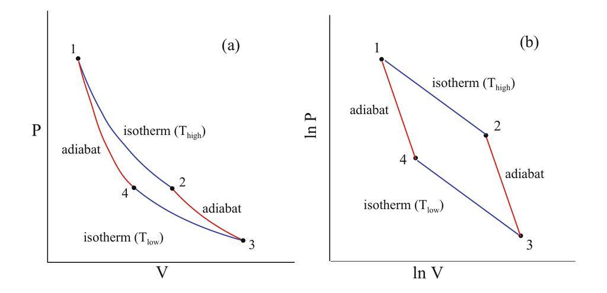

Carnot 循环

## Carnot 效率（一）：四个过程

**四个过程**（工质为理想气体，$T_1>T_3$）：

| 过程 | 类型 | 吸/放热 |
| --- | --- | --- |
| 1→2 | 等温膨胀（$T_1$） | 吸热 $q_1=Nk_BT_1\ln\frac{V_2}{V_1}$ |
| 2→3 | 绝热膨胀 | 0 |
| 3→4 | 等温压缩（$T_3$） | 放热 $q_3=Nk_BT_3\ln\frac{V_3}{V_4}$ |
| 4→1 | 绝热压缩 | 0 |

## Carnot 效率（二）：推导

**由两条绝热线**（$TV^{\gamma-1}=$ const，等价写法 $\dfrac{V_1}{V_4}=\dfrac{V_2}{V_3}=\left(\dfrac{T_1}{T_3}\right)^{-\frac{1}{\gamma-1}}$）得 $\dfrac{V_2}{V_1}=\dfrac{V_3}{V_4}$，于是

$$\eta=1-\frac{q_3}{q_1}=1-\frac{T_3\ln(V_3/V_4)}{T_1\ln(V_2/V_1)}=\boxed{1-\frac{T_3}{T_1}}$$

> **只与两个热源的温度有关**，与工质种类、循环大小无关——这是”热力学温标”的基础。

**推导留给 AI**：

- ① 让他补全两条绝热线为什么给出 $V_2/V_1=V_3/V_4$
- ② 问他”用真实气体做工质，$\eta$ 会变吗”
- ③ 核对温度必须用 K。

## Carnot 循环的净功（一）：四个过程的功与热

**四个过程的功与热汇总**（单位质量）：

| 过程 | 做功 $w$ | 传热 $q$ |
| --- | --- | --- |
| 等温膨胀（1→2） | $w_{1\to2}=Nk_BT_1\ln\dfrac{V_2}{V_1}$ | $q_{1\to2}=w_{1\to2}$（吸热） |
| 绝热膨胀（2→3） | $w_{2\to3}=-C_V(T_3-T_2)$ | 0 |
| 等温压缩（3→4） | $w_{3\to4}=Nk_BT_3\ln\dfrac{V_4}{V_3}$ | $q_{3\to4}=w_{3\to4}$（放热） |
| 绝热压缩（4→1） | $w_{4\to1}=-C_V(T_4-T_1)$ | 0 |

**两条绝热线的功相互抵消**（因为 $T_2=T_1$、$T_4=T_3$，两段绝热的 $\Delta u$ 大小相等、符号相反）：

$$w_{\rm net}=Nk_B(T_1-T_3)\ln\frac{V_2}{V_1}>0$$

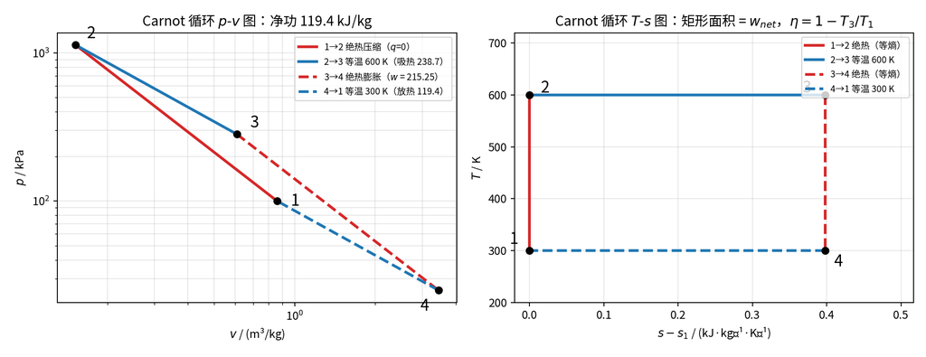

Carnot 循环算例：p-v 图与 T-s 图

| 过程 | 起点 | 终点 | $w$ | $q$ | 为什么 |
| --- | --- | --- | --- | --- | --- |
| 1→2 绝热压缩 | 100 kPa, 300 K, **0.861** | 1131 kPa, 600 K, **0.1522** | −215.2 | 0 | $q=0$，功全变内能 |
| 2→3 等温膨胀 | 1131 kPa, 600 K, 0.1522 | 283 kPa, 600 K, **0.6088** | **+238.7** | **+238.7** | $\Delta u=0$ ⇒ 热全变功 |
| 3→4 绝热膨胀 | 283 kPa, 600 K, 0.6088 | 25 kPa, 300 K, **3.444** | +215.2 | 0 | $q=0$，膨胀靠内能 |
| 4→1 等温压缩 | 25 kPa, 300 K, 3.444 | 100 kPa, 300 K, **0.861** | −119.4 | **−119.4** | 放热给 300 K 热源 |

$$\oint\delta w=+119.4=\oint\delta q\ \text{kJ/kg}\ \checkmark$$

$$\eta=\frac{119.4}{238.7}=50.0\%=1-\frac{300}{600}\ \checkmark$$

> 两条绝热线的功**恰好相消**（$-215.2+215.2$），净功全来自两条等温线之差；$T$-$s$ 图上是矩形， 面积 $=(600-300)\times0.3979=119.4$ kJ/kg。

> $v_4$ 由绝热关系 $v_4=v_3(T_3/T_4)^{1/(\gamma-1)}=3.444$ m³/kg 定，**不能**取 $v_1/4$。

## Carnot 净功（二）：效率

**由此立刻得到效率**：

$$\eta=\frac{w_{\rm net}}{q_1}=\frac{Nk_B(T_1-T_3)\ln(V_2/V_1)}{Nk_BT_1\ln(V_2/V_1)}=1-\frac{T_3}{T_1}$$

> 对数项**完全约掉**——这是 Carnot 效率只依赖温度的直接原因。

**推导留给 AI**：

- ① 让他核对”两条绝热线功抵消”这一步（用 $T_2=T_1$、$T_4=T_3$）
- ② 问：如果工质不是理想气体，$w_{\rm net}$ 的表达式会变吗？$\eta$ 会变吗？

## Carnot 定理（一）：两条定理与证明

**Carnot 定理**（两条）：

1. 在两个给定热源之间，一切**可逆**热机的效率相同，且**最大**
2. 一切**不可逆**热机的效率都小于可逆热机

**证明思路（熵增原理一句话）**：工质经历循环后回到初态 $\Delta S_{\rm sys}=0$，故

$$\Delta S_{\rm tot}=-\frac{q_1}{T_1}+\frac{q_3}{T_3}\ge0\ \Longrightarrow\ \frac{q_3}{q_1}\ge\frac{T_3}{T_1}\ \Longrightarrow\ \eta\le1-\frac{T_3}{T_1}$$

## Carnot 定理（二）：热力学温标

**热力学温标**：因为可逆热机的 $q_3/q_1$ 只依赖两个温度，可以**用热量的比值定义温度比**——这就是开尔文温标（不依赖任何测温物质）。

> 三个温度计的层次：理想气体温标（实验）→ 热力学温标（Carnot）→ SI 定义（$k_B$，见第 1 讲附录 A）。

**推导留给 AI**：

- ① 让他把上面的不等式推导补完整（含不可逆情形）
- ② 问：若某热机声称在两热源间效率 60%（$T_1=600$ K、$T_3=300$ K），问题出在哪？

## 热机效率：从定义到 Carnot 上限

**一条完整逻辑链**（本课时的收口）：

$$\underbrace{\eta=\frac{w_{\rm net}}{q_1}}_{\text{定义}}\ \le\ \underbrace{1-\frac{T_3}{T_1}}_{\text{Carnot 上限}}$$

1. **定义**：$\eta=w_{\rm net}/q_1$，对任何循环都成立（含不可逆）
2. **上限**：一切工作在两热源间的热机，$\eta\le1-T_3/T_1$；等号当且仅当**可逆**
3. **不可逆的代价**：摩擦、传热温差、节流、混合都会产生**熵产**，把一部分可用功变成”废热”

## 热机效率：Carnot 分数与改进方向

**工程换算（Carnot 分数）**：

$$\text{Carnot 分数}=\frac{\eta_{\rm 实际}}{1-T_3/T_1}$$

- 电厂：$T_1\approx800$ K、$T_3\approx300$ K ⇒ 上限 62.5%，实际 $\approx40\%$ ⇒ 分数 $\approx0.64$
- 汽车发动机（汽油机）：上限约 60%，实际约 30%
- **Carnot 分数越大，说明该装置的不可逆损失越小**——这是工程改进的量化指标

**推导留给 AI**：

- ① 让他解释”为什么提高 $T_1$ 比降低 $T_3$ 更有效”（提示：看上限对两者的敏感度）
- ② 问：热泵与制冷机的”效率”该怎么定义？（提示：用 COP，不是 $\eta$。）

# 第六部分 · 例题、小结与作业

- 六道课堂例题（历年真题）
- 循环效率思考题（三角循环、热机可行性）
- 作业：计算题 4 道 + 思考题 3 道
- 本讲小结与下讲预告

## 课堂例题 1：气体常数 R（真题）

**判断**：理想气体状态方程 $pV = nRT$ 中，$R$ 与气体种类有关。（2025—2026 学年 A 卷）

**参考答案**：错误。

- $R = 8.314\,\text{J/(mol·K)}$ 是**通用气体常数**，与气体种类无关
- 不同气体用摩尔质量换算：$R_g = R/M$

## 课堂例题 2：定压过程公式（真题）

**简答**：写出理想气体定压过程的过程方程式、膨胀功、技术功和热量的表达式。（2025—2026 学年 A 卷）

**参考答案**（$p = \text{const}$）：

$$w = p(v_2-v_1) = R_g(T_2-T_1), \qquad w_t = 0, \qquad q = \Delta h = c_p(T_2-T_1)$$

## 课堂例题 3：可逆膨胀做功（真题）

**计算**：1 kg 某种气态工质可逆膨胀，分别遵循 ①$p = av$；②$p = b/v$，从初态 1 到终态 2，求做功。（2025—2026 学年 A 卷）

**参考答案**：

$$w = \int_1^2 p\,dv$$

① $w = \frac{a}{2}(v_2^2-v_1^2)$

② $w = b\ln\frac{v_2}{v_1}$

## 课堂例题 4：定压过程热量（真题）

**计算**：2 kg 理想气体经可逆定压过程，焓值变化 $\Delta h = 150\,\text{kJ/kg}$，求热量并画 t-s 图。（2025—2026 学年 A 卷）

**参考答案**：

- 定压过程 $q = \Delta h = 150\,\text{kJ/kg}$
- $Q = m\Delta h = 2\times150 = 300\,\text{kJ}$
- t-s 图上定压线下方的面积即热量

## 课堂例题 5：定容过程（真题）

**计算**：3.35 kg 理想气体经可逆定容过程，$\Delta u = 140.6\,\text{kJ/kg}$，求过程功和热量，并画 p-v 和 t-s 图。（2024—2025 春 A 卷）

**参考答案**：

- 定容过程：$w = 0$
- $Q = \Delta U = m\Delta u = 3.35\times140.6 \approx 471\,\text{kJ}$
- p-v 图：定容线（竖直线）；t-s 图：定容线下方面积

## 课堂例题 6：理想气体的 u、h（真题）

**简答**：写出理想气体热力学能和焓值的表达。（2024—2025 春 A 卷）

**参考答案**：

$$\Delta u = c_v(T_2-T_1), \qquad \Delta h = c_p(T_2-T_1)$$

内能和焓都是温度的**单值函数**。

## 思考题：三角循环的效率

**解题路线**（$T$-$s$ 图上面积 = 热量）：

1. $T$-$s$ 图上**循环围成的面积**就是净功 $w_{\rm net}$（三角形 = $\frac12\times$底$\times$高）
2. 吸热过程是 $s$ 增大的一段（1→3），$q_1=\int_{1}^{3}T\,\mathrm{d}s$（梯形面积，用平均温度）
3. $\eta=w_{\rm net}/q_1$

## 思考题：热机可行性判断

**题 2（热机可行性）**：判断以下热机是否可行，可行则求热效率。

1. 工作于 $T_1=400$ K 与 $T_2=250$ K 之间，从高温热源吸热 1000 kJ，对外做功 720 kJ
2. 工作于 $T_1=900$ K 与 $T_2=300$ K 之间，从高温热源吸热 2000 kJ，向低温热源放热 800 kJ

**判据与答案**：

- 判据：$\eta_{\rm 实际}\le\eta_{\rm Carnot}=1-T_2/T_1$，**超过上限即不可行**
- （1）上限 $37.5\%$，实际 $\eta=720/1000=72\%$ ⇒ **不可行**（违反第二定律）
- （2）上限 $66.7\%$，实际 $\eta=60\%$ ⇒ **可行**（有熵产，仍满足第二定律）

**推导留给 AI**：

- ① 让他把题 2 的两问都按”熵增原理”重算一遍（不只用效率上限）
- ② 问：题 2（2）若改成放热 700 kJ，还可行吗？

## 思考题（5 道）

1. **大气压力随高度的分布**：凡一阶导数与自身成正比的函数都是指数分布（二阶导与自身成比例则为三角函数）。地球质量 $M_\oplus\approx5.9722\times10^{24}$ kg，球形对称可看作质点。由万有引力 $F=\dfrac{GmM_\oplus}{r^2}=mg$（$G\approx6.67430\times10^{-11}\ \text{m}^3\cdot\text{kg}^{-1}\cdot\text{s}^{-2}$）推导大气压力随高度下降的规律。
2. **估算地球大气分子数**：已知海平面标准压力 $p_0=101\,325$ Pa，估算地球大气层中共有多少个分子。
3. **推导 Maxwell–Boltzmann 分布**：从气体运动论出发推导它（也可从最概然分布出发，与 2.5/2.6 同一手法——两种路线都试一遍并对照）。

## 思考题（续）：编程题与 JANAF

4. **编程题**：$N$ 个粒子、总能量 $3N$，初始能量均匀分布（每个粒子能量都是 3）。编写程序：粒子间进行充分多次**随机能量交换**，得到平衡后的能量分布直方图。
5. **查 JANAF 表**：用 https://janaf.nist.gov/ 研究不同类型分子的热容、焓、自由能等热力学函数随温度的变化规律（为第 3 次课做准备）。

**推导留给 AI**：

- ① 第 1 题让他给出大气标高 $H=k_BT/mg$ 的推导并估算数值
- ② 第 2 题的关键是把”大气总质量”换成”分子数”（$N=M_{\rm atm}/m$，$M_{\rm atm}=p_0A/g$，$A$ 为地球表面积）
- ③ 第 4 题让他写代码并解释直方图为什么会收敛到 Boltzmann 分布。

## 作业（本讲）：计算题四道

**计算题（4 题）**

## 作业（本讲·续）：思考题

**思考题（3 题）**

5. 为什么理想气体的 $U$ 只依赖 $T$，而真实气体不是？写出真实气体 $u(T,v)$ 依赖的来源。
6. 说明”定温过程 $q=w$“与”定熵过程 $q=0$“在第一定律里各意味着什么。
7. 用 $T$-$s$ 图解释：为什么 Carnot 循环的效率与工质无关。

## 作业（本讲·三）：推导作业与阅读

> **推导作业题**（各页”推导留给 AI”）请逐条做：自己先推一遍 → 让 AI 校验 → 交自己的完整推导。

**阅读**：教材第 2、3 章；Callen 第 3 章（Legendre 变换与理想气体算例）；Daily §2.11–2.13。

**推导留给 AI**：让他把你的 7 道题答案逐题挑错，重点看**条件**（可逆？理想气体？定值比热容？）有没有交代清楚。

## 本讲小结

**课时 1**：理想气体一切性质来自配分函数

- $Q = q^N/N!$，$q=V/\Lambda^3$ → $U=\tfrac32 Nk_BT$、$pV=Nk_BT$、Sackur-Tetrode 熵

**课时 2**：熵变分解 → 等温/多变/绝热 → $pV^n$ → Carnot 效率

- 公式汇总表 + Carnot $\eta = 1-T_3/T_1$

## 思考与提问 · 过程与循环（课时 2）

1. 熵变的两条路径分解给出了同一个结果。请找一个**反例式的追问**：如果某个热力学量”两条路径给出不同结果”，你会先怀疑什么？（让 AI 列出所有可能，再自己判断哪一条最可能是”算错了”。）
2. Carnot 效率 $\eta=1-T_3/T_1$ 只依赖温度。请让 AI 解释：为什么**实际**热机的效率总低于它？（提示：不可逆性来自哪些具体环节——摩擦、传热温差、节流、混合。）并举一个你身边的热机（汽车发动机、空调、电厂）算一算它的”Carnot 分数”。
3. 多变过程指数 $n$ 是工程近似。请说明：**真实压气机**的压缩过程为什么常用 $n\approx1.3$，而不是等温（$n=1$）或绝热（$n=\gamma$）？让 AI 给出定量理由，并判断它是否说清”散热”与”转速”的关系。

## 本讲小结（二）：两课时怎么串起来

**课时 1 · 从微观到宏观**

- $q=V/\Lambda^3$ → $Q=q^N/N!$ → $U=\frac32Nk_BT$、$pV=Nk_BT$、$\mu=\mu^\circ+k_BT\ln\frac{p}{p^\circ}$
- 熵：Sackur–Tetrode（与 JANAF 表定量吻合）
- 一切来自配分函数，**没有任何可调参数**

**课时 2 · 从熵到过程**

- 熵变两条路径 → 统一形式；等温、绝热（三个关系式）、多变（$C_n$、$w$、$q$、$w_t$）
- 一张汇总表覆盖全部可逆过程
- Carnot：$\eta=1-T_3/T_1$，由熵增原理证明，是所有热机的上限

## 本讲小结（三）：三条最该记住的结论

**三条最该记住的结论**：① 理想气体 $u=u(T)$、$h=h(T)$；② $pV^n$ 一族过程；③ $\eta_{\rm Carnot}$ 只依赖温度。

**推导留给 AI**：让 AI 用三句话把本讲串起来，然后判断它有没有把”配分函数路线”和”过程计算”两半的因果关系讲反。

**本讲两课时的收束**：课时 1 解决”理想气体的性质从哪来”，课时 2 解决”用它怎么算过程与循环”。

## 下讲预告

- 用 JANAF 热化学表（$S^\circ$、$H^\circ$）做**真实的化学反应计算**
- 反应平衡常数、等焓/平衡温度、van’t Hoff 方程
- 化学势 $\mu=\mu^\circ+RT\ln(p/p^\circ)$ 的工程用法（本讲已给出）

**再下一次**：水蒸气与湿空气（真实气体、相变、干度、相对湿度）

> 带上计算器与 JANAF 表；本讲的 $S$、$\mu$ 是下次课的输入。